# Risk Factor Analysis

## Outcome Variable

**Outcome Variable:** ever_sstunted

## Predictor Variables

**Intervention Variable:** feducyrs

**Adjustment Set:**

- arm
- W_mage
- meducyrs
- hhwealth_quart
- W_mhtcm
- W_gagebrth
- W_birthwt
- W_birthlen
- single
- delta_W_mage
- delta_meducyrs
- delta_hhwealth_quart
- delta_W_mhtcm
- delta_W_gagebrth
- delta_W_birthwt
- delta_W_birthlen
- delta_single

## Stratifying Variables

The analysis was stratified on these variable(s):

- agecat
- studyid
- country

## Data Summary

| agecat | studyid | country | feducyrs | ever_sstunted | n_cell | n |
| --- | --- | --- | --- | --- | --- | --- |
| 0-24 months | ki0047075b-MAL-ED | BANGLADESH | High | 0 | 47 | 149 |
| 0-24 months | ki0047075b-MAL-ED | BANGLADESH | High | 1 | 7 | 149 |
| 0-24 months | ki0047075b-MAL-ED | BANGLADESH | Low | 0 | 32 | 149 |
| 0-24 months | ki0047075b-MAL-ED | BANGLADESH | Low | 1 | 8 | 149 |
| 0-24 months | ki0047075b-MAL-ED | BANGLADESH | Medium | 0 | 40 | 149 |
| 0-24 months | ki0047075b-MAL-ED | BANGLADESH | Medium | 1 | 15 | 149 |
| 0-24 months | ki0047075b-MAL-ED | INDIA | High | 0 | 38 | 147 |
| 0-24 months | ki0047075b-MAL-ED | INDIA | High | 1 | 6 | 147 |
| 0-24 months | ki0047075b-MAL-ED | INDIA | Low | 0 | 45 | 147 |
| 0-24 months | ki0047075b-MAL-ED | INDIA | Low | 1 | 14 | 147 |
| 0-24 months | ki0047075b-MAL-ED | INDIA | Medium | 0 | 36 | 147 |
| 0-24 months | ki0047075b-MAL-ED | INDIA | Medium | 1 | 8 | 147 |
| 0-24 months | ki0047075b-MAL-ED | NEPAL | High | 0 | 39 | 98 |
| 0-24 months | ki0047075b-MAL-ED | NEPAL | High | 1 | 3 | 98 |
| 0-24 months | ki0047075b-MAL-ED | NEPAL | Low | 0 | 26 | 98 |
| 0-24 months | ki0047075b-MAL-ED | NEPAL | Low | 1 | 2 | 98 |
| 0-24 months | ki0047075b-MAL-ED | NEPAL | Medium | 0 | 24 | 98 |
| 0-24 months | ki0047075b-MAL-ED | NEPAL | Medium | 1 | 4 | 98 |
| 0-24 months | ki0047075b-MAL-ED | PERU | High | 0 | 98 | 250 |
| 0-24 months | ki0047075b-MAL-ED | PERU | High | 1 | 22 | 250 |
| 0-24 months | ki0047075b-MAL-ED | PERU | Low | 0 | 53 | 250 |
| 0-24 months | ki0047075b-MAL-ED | PERU | Low | 1 | 16 | 250 |
| 0-24 months | ki0047075b-MAL-ED | PERU | Medium | 0 | 49 | 250 |
| 0-24 months | ki0047075b-MAL-ED | PERU | Medium | 1 | 12 | 250 |
| 0-24 months | ki0047075b-MAL-ED | SOUTH AFRICA | High | 0 | 35 | 110 |
| 0-24 months | ki0047075b-MAL-ED | SOUTH AFRICA | High | 1 | 8 | 110 |
| 0-24 months | ki0047075b-MAL-ED | SOUTH AFRICA | Low | 0 | 30 | 110 |
| 0-24 months | ki0047075b-MAL-ED | SOUTH AFRICA | Low | 1 | 7 | 110 |
| 0-24 months | ki0047075b-MAL-ED | SOUTH AFRICA | Medium | 0 | 20 | 110 |
| 0-24 months | ki0047075b-MAL-ED | SOUTH AFRICA | Medium | 1 | 10 | 110 |

[output cut: 210 more lines]

The following strata were considered:

- agecat: 0-24 months, studyid: ki0047075b-MAL-ED, country: BANGLADESH
- agecat: 0-24 months, studyid: ki0047075b-MAL-ED, country: INDIA
- agecat: 0-24 months, studyid: ki0047075b-MAL-ED, country: NEPAL
- agecat: 0-24 months, studyid: ki0047075b-MAL-ED, country: PERU
- agecat: 0-24 months, studyid: ki0047075b-MAL-ED, country: SOUTH AFRICA
- agecat: 0-24 months, studyid: ki0047075b-MAL-ED, country: TANZANIA, UNITED REPUBLIC OF
- agecat: 0-24 months, studyid: ki1000304b-SAS-CompFeed, country: INDIA
- agecat: 0-24 months, studyid: ki1000304b-SAS-FoodSuppl, country: INDIA
- agecat: 0-24 months, studyid: ki1017093b-PROVIDE, country: BANGLADESH
- agecat: 0-24 months, studyid: ki1017093c-NIH-Crypto, country: BANGLADESH
- agecat: 0-24 months, studyid: ki1066203-TanzaniaChild2, country: TANZANIA, UNITED REPUBLIC OF
- agecat: 0-24 months, studyid: ki1113344-GMS-Nepal, country: NEPAL
- agecat: 0-24 months, studyid: ki1119695-PROBIT, country: BELARUS
- agecat: 0-24 months, studyid: ki1126311-ZVITAMBO, country: ZIMBABWE
- agecat: 0-24 months, studyid: ki1135781-COHORTS, country: GUATEMALA
- agecat: 0-24 months, studyid: ki1135781-COHORTS, country: INDIA
- agecat: 0-24 months, studyid: ki1135781-COHORTS, country: PHILIPPINES
- agecat: 0-24 months, studyid: ki1148112-LCNI-5, country: MALAWI
- agecat: 0-24 months, studyid: kiGH5241-JiVitA-3, country: BANGLADESH
- agecat: 0-24 months, studyid: kiGH5241-JiVitA-4, country: BANGLADESH
- agecat: 0-6 months, studyid: ki0047075b-MAL-ED, country: BANGLADESH
- agecat: 0-6 months, studyid: ki0047075b-MAL-ED, country: INDIA
- agecat: 0-6 months, studyid: ki0047075b-MAL-ED, country: NEPAL
- agecat: 0-6 months, studyid: ki0047075b-MAL-ED, country: PERU
- agecat: 0-6 months, studyid: ki0047075b-MAL-ED, country: SOUTH AFRICA
- agecat: 0-6 months, studyid: ki0047075b-MAL-ED, country: TANZANIA, UNITED REPUBLIC OF
- agecat: 0-6 months, studyid: ki1000304b-SAS-CompFeed, country: INDIA
- agecat: 0-6 months, studyid: ki1000304b-SAS-FoodSuppl, country: INDIA
- agecat: 0-6 months, studyid: ki1017093b-PROVIDE, country: BANGLADESH
- agecat: 0-6 months, studyid: ki1017093c-NIH-Crypto, country: BANGLADESH
- agecat: 0-6 months, studyid: ki1066203-TanzaniaChild2, country: TANZANIA, UNITED REPUBLIC OF
- agecat: 0-6 months, studyid: ki1113344-GMS-Nepal, country: NEPAL
- agecat: 0-6 months, studyid: ki1119695-PROBIT, country: BELARUS
- agecat: 0-6 months, studyid: ki1126311-ZVITAMBO, country: ZIMBABWE
- agecat: 0-6 months, studyid: ki1135781-COHORTS, country: GUATEMALA
- agecat: 0-6 months, studyid: ki1135781-COHORTS, country: INDIA
- agecat: 0-6 months, studyid: ki1135781-COHORTS, country: PHILIPPINES
- agecat: 0-6 months, studyid: ki1148112-LCNI-5, country: MALAWI
- agecat: 0-6 months, studyid: kiGH5241-JiVitA-3, country: BANGLADESH
- agecat: 0-6 months, studyid: kiGH5241-JiVitA-4, country: BANGLADESH

### Dropped Strata

Some strata were dropped due to rare outcomes:

- agecat: 0-24 months, studyid: ki0047075b-MAL-ED, country: NEPAL
- agecat: 0-6 months, studyid: ki0047075b-MAL-ED, country: BANGLADESH
- agecat: 0-6 months, studyid: ki0047075b-MAL-ED, country: INDIA
- agecat: 0-6 months, studyid: ki0047075b-MAL-ED, country: NEPAL
- agecat: 0-6 months, studyid: ki0047075b-MAL-ED, country: SOUTH AFRICA
- agecat: 0-6 months, studyid: ki0047075b-MAL-ED, country: TANZANIA, UNITED REPUBLIC OF
- agecat: 0-6 months, studyid: ki1148112-LCNI-5, country: MALAWI

## Methods Detail

We’re interested in the causal parameters $E[Y_a]$ for all values of $a \in \mathcal{A}$. These parameters represent the mean outcome if, possibly contrary to fact, we intervened to set all units to have $A=a$. Under the randomization and positivity assumptions, these are identified by the statistical parameters $\psi_a=E_W[E_{Y|A,W}(Y|A=a,W)]$. In addition, we’re interested in the mean of $Y$, $E[Y]$ under no intervention (the observed mean). We will estimate these parameters by using SuperLearner to fit the relevant likelihood factors – $E_{Y|A,W}(Y|A=a,W)$ and $p(A=a|W)$, and then updating our likelihood fit using a joint TMLE.

For unadjusted analyses ($W=\{\}$), initial likelihoods were estimated using Lrnr_glm to estimate the simple $E(Y|A)$ and Lrnr_mean to estimate $p(A)$. For adjusted analyses, a small library containing Lrnr_glmnet, Lrnr_xgboost, and Lrnr_mean was used.

Having estimated these parameters, we will then use the delta method to estimate relative risks and attributable risks relative to a prespecified baseline level of $A$.

# Results Detail

## Results Plots

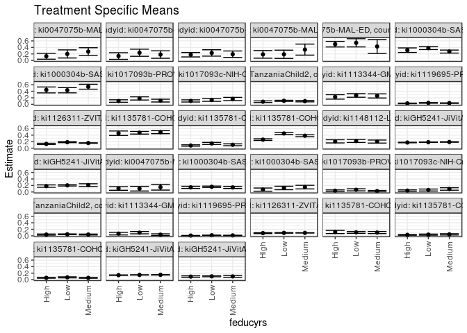

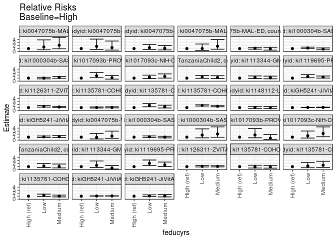

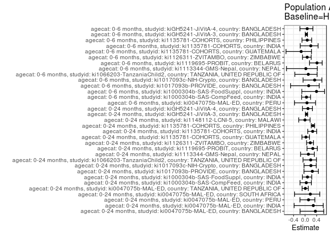

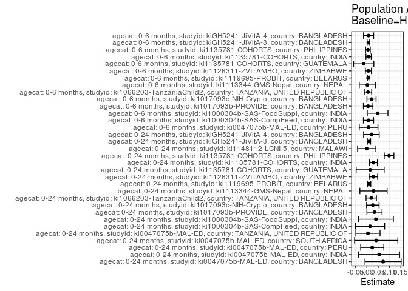

## Results Table

### Parameter: TSM

| agecat | studyid | country | intervention_level | baseline_level | estimate | ci_lower | ci_upper |
| --- | --- | --- | --- | --- | --- | --- | --- |
| 0-24 months | ki0047075b-MAL-ED | BANGLADESH | High | NA | 0.1296296 | 0.0397383 | 0.2195209 |
| 0-24 months | ki0047075b-MAL-ED | BANGLADESH | Low | NA | 0.2000000 | 0.0756229 | 0.3243771 |
| 0-24 months | ki0047075b-MAL-ED | BANGLADESH | Medium | NA | 0.2727273 | 0.1546294 | 0.3908251 |
| 0-24 months | ki0047075b-MAL-ED | INDIA | High | NA | 0.1363636 | 0.0346173 | 0.2381100 |
| 0-24 months | ki0047075b-MAL-ED | INDIA | Low | NA | 0.2372881 | 0.1283644 | 0.3462119 |
| 0-24 months | ki0047075b-MAL-ED | INDIA | Medium | NA | 0.1818182 | 0.0674652 | 0.2961712 |
| 0-24 months | ki0047075b-MAL-ED | PERU | High | NA | 0.1762267 | 0.1084157 | 0.2440376 |
| 0-24 months | ki0047075b-MAL-ED | PERU | Low | NA | 0.2311171 | 0.1337102 | 0.3285239 |
| 0-24 months | ki0047075b-MAL-ED | PERU | Medium | NA | 0.1916660 | 0.0927513 | 0.2905806 |
| 0-24 months | ki0047075b-MAL-ED | SOUTH AFRICA | High | NA | 0.1860465 | 0.0692022 | 0.3028908 |
| 0-24 months | ki0047075b-MAL-ED | SOUTH AFRICA | Low | NA | 0.1891892 | 0.0624128 | 0.3159655 |
| 0-24 months | ki0047075b-MAL-ED | SOUTH AFRICA | Medium | NA | 0.3333333 | 0.1638745 | 0.5027922 |
| 0-24 months | ki0047075b-MAL-ED | TANZANIA, UNITED REPUBLIC OF | High | NA | 0.5000000 | 0.4138465 | 0.5861535 |
| 0-24 months | ki0047075b-MAL-ED | TANZANIA, UNITED REPUBLIC OF | Low | NA | 0.5409836 | 0.4156360 | 0.6663312 |
| 0-24 months | ki0047075b-MAL-ED | TANZANIA, UNITED REPUBLIC OF | Medium | NA | 0.4285714 | 0.2164143 | 0.6407286 |
| 0-24 months | ki1000304b-SAS-CompFeed | INDIA | High | NA | 0.3159882 | 0.2468321 | 0.3851443 |
| 0-24 months | ki1000304b-SAS-CompFeed | INDIA | Low | NA | 0.3784130 | 0.3346750 | 0.4221509 |
| 0-24 months | ki1000304b-SAS-CompFeed | INDIA | Medium | NA | 0.2730022 | 0.2268588 | 0.3191457 |
| 0-24 months | ki1000304b-SAS-FoodSuppl | INDIA | High | NA | 0.4411227 | 0.3503948 | 0.5318506 |
| 0-24 months | ki1000304b-SAS-FoodSuppl | INDIA | Low | NA | 0.4319538 | 0.3521057 | 0.5118020 |
| 0-24 months | ki1000304b-SAS-FoodSuppl | INDIA | Medium | NA | 0.5393298 | 0.4638502 | 0.6148094 |
| 0-24 months | ki1017093b-PROVIDE | BANGLADESH | High | NA | 0.1005940 | 0.0628274 | 0.1383606 |
| 0-24 months | ki1017093b-PROVIDE | BANGLADESH | Low | NA | 0.1811150 | 0.1319085 | 0.2303215 |
| 0-24 months | ki1017093b-PROVIDE | BANGLADESH | Medium | NA | 0.1136300 | 0.0713718 | 0.1558882 |
| 0-24 months | ki1017093c-NIH-Crypto | BANGLADESH | High | NA | 0.1042140 | 0.0710061 | 0.1374218 |
| 0-24 months | ki1017093c-NIH-Crypto | BANGLADESH | Low | NA | 0.1337149 | 0.0919681 | 0.1754617 |
| 0-24 months | ki1017093c-NIH-Crypto | BANGLADESH | Medium | NA | 0.1628564 | 0.1136840 | 0.2120288 |
| 0-24 months | ki1066203-TanzaniaChild2 | TANZANIA, UNITED REPUBLIC OF | High | NA | 0.0801366 | 0.0553758 | 0.1048974 |
| 0-24 months | ki1066203-TanzaniaChild2 | TANZANIA, UNITED REPUBLIC OF | Low | NA | 0.1074871 | 0.0903393 | 0.1246350 |
| 0-24 months | ki1066203-TanzaniaChild2 | TANZANIA, UNITED REPUBLIC OF | Medium | NA | 0.0977811 | 0.0752083 | 0.1203539 |

[output cut: 69 more lines]

### Parameter: E(Y)

| agecat | studyid | country | intervention_level | baseline_level | estimate | ci_lower | ci_upper |
| --- | --- | --- | --- | --- | --- | --- | --- |
| 0-24 months | ki0047075b-MAL-ED | BANGLADESH | NA | NA | 0.2013423 | 0.1367374 | 0.2659471 |
| 0-24 months | ki0047075b-MAL-ED | INDIA | NA | NA | 0.1904762 | 0.1267810 | 0.2541714 |
| 0-24 months | ki0047075b-MAL-ED | PERU | NA | NA | 0.2000000 | 0.1503169 | 0.2496831 |
| 0-24 months | ki0047075b-MAL-ED | SOUTH AFRICA | NA | NA | 0.2272727 | 0.1486005 | 0.3059450 |
| 0-24 months | ki0047075b-MAL-ED | TANZANIA, UNITED REPUBLIC OF | NA | NA | 0.5047170 | 0.4372552 | 0.5721787 |
| 0-24 months | ki1000304b-SAS-CompFeed | INDIA | NA | NA | 0.3300654 | 0.3020915 | 0.3580392 |
| 0-24 months | ki1000304b-SAS-FoodSuppl | INDIA | NA | NA | 0.4808612 | 0.4329065 | 0.5288160 |
| 0-24 months | ki1017093b-PROVIDE | BANGLADESH | NA | NA | 0.1342857 | 0.1090095 | 0.1595619 |
| 0-24 months | ki1017093c-NIH-Crypto | BANGLADESH | NA | NA | 0.1306069 | 0.1066024 | 0.1546113 |
| 0-24 months | ki1066203-TanzaniaChild2 | TANZANIA, UNITED REPUBLIC OF | NA | NA | 0.0994545 | 0.0874362 | 0.1114727 |
| 0-24 months | ki1113344-GMS-Nepal | NEPAL | NA | NA | 0.2562396 | 0.2213085 | 0.2911707 |
| 0-24 months | ki1119695-PROBIT | BELARUS | NA | NA | 0.0382494 | 0.0300114 | 0.0464873 |
| 0-24 months | ki1126311-ZVITAMBO | ZIMBABWE | NA | NA | 0.1589133 | 0.1527896 | 0.1650370 |
| 0-24 months | ki1135781-COHORTS | GUATEMALA | NA | NA | 0.4728000 | 0.4451119 | 0.5004881 |
| 0-24 months | ki1135781-COHORTS | INDIA | NA | NA | 0.1105736 | 0.0944098 | 0.1267374 |
| 0-24 months | ki1135781-COHORTS | PHILIPPINES | NA | NA | 0.3600694 | 0.3425352 | 0.3776037 |
| 0-24 months | ki1148112-LCNI-5 | MALAWI | NA | NA | 0.2078721 | 0.1799617 | 0.2357825 |
| 0-24 months | kiGH5241-JiVitA-3 | BANGLADESH | NA | NA | 0.1820815 | 0.1764045 | 0.1877585 |
| 0-24 months | kiGH5241-JiVitA-4 | BANGLADESH | NA | NA | 0.2011046 | 0.1842883 | 0.2179209 |
| 0-6 months | ki0047075b-MAL-ED | PERU | NA | NA | 0.1160000 | 0.0762256 | 0.1557744 |
| 0-6 months | ki1000304b-SAS-CompFeed | INDIA | NA | NA | 0.1493124 | 0.1303783 | 0.1682465 |
| 0-6 months | ki1000304b-SAS-FoodSuppl | INDIA | NA | NA | 0.1201923 | 0.0889059 | 0.1514788 |
| 0-6 months | ki1017093b-PROVIDE | BANGLADESH | NA | NA | 0.0442857 | 0.0290345 | 0.0595370 |
| 0-6 months | ki1017093c-NIH-Crypto | BANGLADESH | NA | NA | 0.0620053 | 0.0448256 | 0.0791849 |
| 0-6 months | ki1066203-TanzaniaChild2 | TANZANIA, UNITED REPUBLIC OF | NA | NA | 0.0432228 | 0.0350563 | 0.0513894 |
| 0-6 months | ki1113344-GMS-Nepal | NEPAL | NA | NA | 0.0698835 | 0.0494836 | 0.0902835 |
| 0-6 months | ki1119695-PROBIT | BELARUS | NA | NA | 0.0137339 | 0.0103297 | 0.0171381 |
| 0-6 months | ki1126311-ZVITAMBO | ZIMBABWE | NA | NA | 0.0898852 | 0.0850909 | 0.0946795 |
| 0-6 months | ki1135781-COHORTS | GUATEMALA | NA | NA | 0.1039216 | 0.0851851 | 0.1226580 |
| 0-6 months | ki1135781-COHORTS | INDIA | NA | NA | 0.0380014 | 0.0280567 | 0.0479461 |
| 0-6 months | ki1135781-COHORTS | PHILIPPINES | NA | NA | 0.0618056 | 0.0530095 | 0.0706016 |
| 0-6 months | kiGH5241-JiVitA-3 | BANGLADESH | NA | NA | 0.1452309 | 0.1401200 | 0.1503418 |
| 0-6 months | kiGH5241-JiVitA-4 | BANGLADESH | NA | NA | 0.1011352 | 0.0882687 | 0.1140017 |

### Parameter: RR

| agecat | studyid | country | intervention_level | baseline_level | estimate | ci_lower | ci_upper |
| --- | --- | --- | --- | --- | --- | --- | --- |
| 0-24 months | ki0047075b-MAL-ED | BANGLADESH | High | High | 1.0000000 | 1.0000000 | 1.000000 |
| 0-24 months | ki0047075b-MAL-ED | BANGLADESH | Low | High | 1.5428571 | 0.6078543 | 3.916084 |
| 0-24 months | ki0047075b-MAL-ED | BANGLADESH | Medium | High | 2.1038961 | 0.9289000 | 4.765183 |
| 0-24 months | ki0047075b-MAL-ED | INDIA | High | High | 1.0000000 | 1.0000000 | 1.000000 |
| 0-24 months | ki0047075b-MAL-ED | INDIA | Low | High | 1.7401130 | 0.7246362 | 4.178639 |
| 0-24 months | ki0047075b-MAL-ED | INDIA | Medium | High | 1.3333333 | 0.5024936 | 3.537911 |
| 0-24 months | ki0047075b-MAL-ED | PERU | High | High | 1.0000000 | 1.0000000 | 1.000000 |
| 0-24 months | ki0047075b-MAL-ED | PERU | Low | High | 1.3114763 | 0.7374666 | 2.332268 |
| 0-24 months | ki0047075b-MAL-ED | PERU | Medium | High | 1.0876105 | 0.5713654 | 2.070298 |
| 0-24 months | ki0047075b-MAL-ED | SOUTH AFRICA | High | High | 1.0000000 | 1.0000000 | 1.000000 |
| 0-24 months | ki0047075b-MAL-ED | SOUTH AFRICA | Low | High | 1.0168919 | 0.4058970 | 2.547614 |
| 0-24 months | ki0047075b-MAL-ED | SOUTH AFRICA | Medium | High | 1.7916667 | 0.7986258 | 4.019491 |
| 0-24 months | ki0047075b-MAL-ED | TANZANIA, UNITED REPUBLIC OF | High | High | 1.0000000 | 1.0000000 | 1.000000 |
| 0-24 months | ki0047075b-MAL-ED | TANZANIA, UNITED REPUBLIC OF | Low | High | 1.0819672 | 0.8106100 | 1.444163 |
| 0-24 months | ki0047075b-MAL-ED | TANZANIA, UNITED REPUBLIC OF | Medium | High | 0.8571429 | 0.5074716 | 1.447754 |
| 0-24 months | ki1000304b-SAS-CompFeed | INDIA | High | High | 1.0000000 | 1.0000000 | 1.000000 |
| 0-24 months | ki1000304b-SAS-CompFeed | INDIA | Low | High | 1.1975540 | 0.9610792 | 1.492214 |
| 0-24 months | ki1000304b-SAS-CompFeed | INDIA | Medium | High | 0.8639633 | 0.6059020 | 1.231936 |
| 0-24 months | ki1000304b-SAS-FoodSuppl | INDIA | High | High | 1.0000000 | 1.0000000 | 1.000000 |
| 0-24 months | ki1000304b-SAS-FoodSuppl | INDIA | Low | High | 0.9792147 | 0.7445847 | 1.287780 |
| 0-24 months | ki1000304b-SAS-FoodSuppl | INDIA | Medium | High | 1.2226299 | 0.9568431 | 1.562246 |
| 0-24 months | ki1017093b-PROVIDE | BANGLADESH | High | High | 1.0000000 | 1.0000000 | 1.000000 |
| 0-24 months | ki1017093b-PROVIDE | BANGLADESH | Low | High | 1.8004546 | 1.1347633 | 2.856664 |
| 0-24 months | ki1017093b-PROVIDE | BANGLADESH | Medium | High | 1.1295901 | 0.6671884 | 1.912464 |
| 0-24 months | ki1017093c-NIH-Crypto | BANGLADESH | High | High | 1.0000000 | 1.0000000 | 1.000000 |
| 0-24 months | ki1017093c-NIH-Crypto | BANGLADESH | Low | High | 1.2830804 | 0.8259729 | 1.993159 |
| 0-24 months | ki1017093c-NIH-Crypto | BANGLADESH | Medium | High | 1.5627119 | 1.0134927 | 2.409557 |
| 0-24 months | ki1066203-TanzaniaChild2 | TANZANIA, UNITED REPUBLIC OF | High | High | 1.0000000 | 1.0000000 | 1.000000 |
| 0-24 months | ki1066203-TanzaniaChild2 | TANZANIA, UNITED REPUBLIC OF | Low | High | 1.3412992 | 0.9480885 | 1.897590 |
| 0-24 months | ki1066203-TanzaniaChild2 | TANZANIA, UNITED REPUBLIC OF | Medium | High | 1.2201807 | 0.8309468 | 1.791740 |

[output cut: 69 more lines]

### Parameter: PAR

| agecat | studyid | country | intervention_level | baseline_level | estimate | ci_lower | ci_upper |
| --- | --- | --- | --- | --- | --- | --- | --- |
| 0-24 months | ki0047075b-MAL-ED | BANGLADESH | High | NA | 0.0717127 | -0.0082702 | 0.1516956 |
| 0-24 months | ki0047075b-MAL-ED | INDIA | High | NA | 0.0541126 | -0.0365080 | 0.1447331 |
| 0-24 months | ki0047075b-MAL-ED | PERU | High | NA | 0.0237733 | -0.0274402 | 0.0749869 |
| 0-24 months | ki0047075b-MAL-ED | SOUTH AFRICA | High | NA | 0.0412262 | -0.0545238 | 0.1369763 |
| 0-24 months | ki0047075b-MAL-ED | TANZANIA, UNITED REPUBLIC OF | High | NA | 0.0047170 | -0.0488604 | 0.0582944 |
| 0-24 months | ki1000304b-SAS-CompFeed | INDIA | High | NA | 0.0140771 | -0.0504419 | 0.0785961 |
| 0-24 months | ki1000304b-SAS-FoodSuppl | INDIA | High | NA | 0.0397385 | -0.0378139 | 0.1172910 |
| 0-24 months | ki1017093b-PROVIDE | BANGLADESH | High | NA | 0.0336917 | 0.0001431 | 0.0672402 |
| 0-24 months | ki1017093c-NIH-Crypto | BANGLADESH | High | NA | 0.0263929 | -0.0013702 | 0.0541560 |
| 0-24 months | ki1066203-TanzaniaChild2 | TANZANIA, UNITED REPUBLIC OF | High | NA | 0.0193179 | -0.0036408 | 0.0422765 |
| 0-24 months | ki1113344-GMS-Nepal | NEPAL | High | NA | 0.0292908 | -0.0310239 | 0.0896055 |
| 0-24 months | ki1119695-PROBIT | BELARUS | High | NA | 0.0102386 | 0.0031881 | 0.0172891 |
| 0-24 months | ki1126311-ZVITAMBO | ZIMBABWE | High | NA | 0.0287534 | 0.0099323 | 0.0475744 |
| 0-24 months | ki1135781-COHORTS | GUATEMALA | High | NA | 0.0145598 | -0.0473810 | 0.0765006 |
| 0-24 months | ki1135781-COHORTS | INDIA | High | NA | 0.0289542 | 0.0114113 | 0.0464972 |
| 0-24 months | ki1135781-COHORTS | PHILIPPINES | High | NA | 0.0982619 | 0.0769709 | 0.1195529 |
| 0-24 months | ki1148112-LCNI-5 | MALAWI | High | NA | -0.0008024 | -0.0412970 | 0.0396922 |
| 0-24 months | kiGH5241-JiVitA-3 | BANGLADESH | High | NA | 0.0093328 | 0.0022219 | 0.0164437 |
| 0-24 months | kiGH5241-JiVitA-4 | BANGLADESH | High | NA | 0.0200482 | -0.0145275 | 0.0546239 |
| 0-6 months | ki0047075b-MAL-ED | PERU | High | NA | 0.0076667 | -0.0336394 | 0.0489727 |
| 0-6 months | ki1000304b-SAS-CompFeed | INDIA | High | NA | 0.0072383 | -0.0154292 | 0.0299059 |
| 0-6 months | ki1000304b-SAS-FoodSuppl | INDIA | High | NA | 0.0474650 | 0.0017362 | 0.0931939 |
| 0-6 months | ki1017093b-PROVIDE | BANGLADESH | High | NA | 0.0054926 | -0.0155087 | 0.0264940 |
| 0-6 months | ki1017093c-NIH-Crypto | BANGLADESH | High | NA | 0.0205132 | 0.0002944 | 0.0407320 |
| 0-6 months | ki1066203-TanzaniaChild2 | TANZANIA, UNITED REPUBLIC OF | High | NA | 0.0047942 | -0.0113966 | 0.0209850 |
| 0-6 months | ki1113344-GMS-Nepal | NEPAL | High | NA | 0.0018563 | -0.0336947 | 0.0374073 |
| 0-6 months | ki1119695-PROBIT | BELARUS | High | NA | 0.0056582 | 0.0023027 | 0.0090138 |
| 0-6 months | ki1126311-ZVITAMBO | ZIMBABWE | High | NA | 0.0065766 | -0.0068166 | 0.0199698 |
| 0-6 months | ki1135781-COHORTS | GUATEMALA | High | NA | -0.0140050 | -0.0588018 | 0.0307919 |
| 0-6 months | ki1135781-COHORTS | INDIA | High | NA | 0.0075374 | -0.0040556 | 0.0191305 |
| 0-6 months | ki1135781-COHORTS | PHILIPPINES | High | NA | 0.0046593 | -0.0056926 | 0.0150112 |
| 0-6 months | kiGH5241-JiVitA-3 | BANGLADESH | High | NA | 0.0066693 | 0.0010249 | 0.0123138 |
| 0-6 months | kiGH5241-JiVitA-4 | BANGLADESH | High | NA | 0.0074447 | -0.0151161 | 0.0300055 |

### Parameter: PAF

| agecat | studyid | country | intervention_level | baseline_level | estimate | ci_lower | ci_upper |
| --- | --- | --- | --- | --- | --- | --- | --- |
| 0-24 months | ki0047075b-MAL-ED | BANGLADESH | High | NA | 0.3561728 | -0.1725639 | 0.6464897 |
| 0-24 months | ki0047075b-MAL-ED | INDIA | High | NA | 0.2840909 | -0.3792017 | 0.6283895 |
| 0-24 months | ki0047075b-MAL-ED | PERU | High | NA | 0.1188666 | -0.1767411 | 0.3402151 |
| 0-24 months | ki0047075b-MAL-ED | SOUTH AFRICA | High | NA | 0.1813953 | -0.3655131 | 0.5092588 |
| 0-24 months | ki0047075b-MAL-ED | TANZANIA, UNITED REPUBLIC OF | High | NA | 0.0093458 | -0.1027120 | 0.1100162 |
| 0-24 months | ki1000304b-SAS-CompFeed | INDIA | High | NA | 0.0426495 | -0.1740516 | 0.2193529 |
| 0-24 months | ki1000304b-SAS-FoodSuppl | INDIA | High | NA | 0.0826404 | -0.0938254 | 0.2306371 |
| 0-24 months | ki1017093b-PROVIDE | BANGLADESH | High | NA | 0.2508955 | -0.0386818 | 0.4597406 |
| 0-24 months | ki1017093c-NIH-Crypto | BANGLADESH | High | NA | 0.2020790 | -0.0368196 | 0.3859319 |
| 0-24 months | ki1066203-TanzaniaChild2 | TANZANIA, UNITED REPUBLIC OF | High | NA | 0.1942385 | -0.0713483 | 0.3939864 |
| 0-24 months | ki1113344-GMS-Nepal | NEPAL | High | NA | 0.1143101 | -0.1549465 | 0.3207940 |
| 0-24 months | ki1119695-PROBIT | BELARUS | High | NA | 0.2676800 | 0.0672776 | 0.4250245 |
| 0-24 months | ki1126311-ZVITAMBO | ZIMBABWE | High | NA | 0.1809375 | 0.0536722 | 0.2910877 |
| 0-24 months | ki1135781-COHORTS | GUATEMALA | High | NA | 0.0307948 | -0.1095194 | 0.1533643 |
| 0-24 months | ki1135781-COHORTS | INDIA | High | NA | 0.2618548 | 0.0919828 | 0.3999471 |
| 0-24 months | ki1135781-COHORTS | PHILIPPINES | High | NA | 0.2728971 | 0.2118891 | 0.3291825 |
| 0-24 months | ki1148112-LCNI-5 | MALAWI | High | NA | -0.0038601 | -0.2188536 | 0.1732108 |
| 0-24 months | kiGH5241-JiVitA-3 | BANGLADESH | High | NA | 0.0512562 | 0.0113926 | 0.0895124 |
| 0-24 months | kiGH5241-JiVitA-4 | BANGLADESH | High | NA | 0.0996906 | -0.0888964 | 0.2556160 |
| 0-6 months | ki0047075b-MAL-ED | PERU | High | NA | 0.0660920 | -0.3666002 | 0.3617854 |
| 0-6 months | ki1000304b-SAS-CompFeed | INDIA | High | NA | 0.0484779 | -0.1182548 | 0.1903506 |
| 0-6 months | ki1000304b-SAS-FoodSuppl | INDIA | High | NA | 0.3949091 | -0.1128652 | 0.6709979 |
| 0-6 months | ki1017093b-PROVIDE | BANGLADESH | High | NA | 0.1240267 | -0.5021944 | 0.4891945 |
| 0-6 months | ki1017093c-NIH-Crypto | BANGLADESH | High | NA | 0.3308299 | -0.0689935 | 0.5811119 |
| 0-6 months | ki1066203-TanzaniaChild2 | TANZANIA, UNITED REPUBLIC OF | High | NA | 0.1109190 | -0.3539497 | 0.4161785 |
| 0-6 months | ki1113344-GMS-Nepal | NEPAL | High | NA | 0.0265630 | -0.6415258 | 0.4227446 |
| 0-6 months | ki1119695-PROBIT | BELARUS | High | NA | 0.4119907 | 0.1534711 | 0.5915616 |
| 0-6 months | ki1126311-ZVITAMBO | ZIMBABWE | High | NA | 0.0731665 | -0.0884128 | 0.2107587 |
| 0-6 months | ki1135781-COHORTS | GUATEMALA | High | NA | -0.1347648 | -0.6584893 | 0.2235758 |
| 0-6 months | ki1135781-COHORTS | INDIA | High | NA | 0.1983456 | -0.1668104 | 0.4492252 |
| 0-6 months | ki1135781-COHORTS | PHILIPPINES | High | NA | 0.0753861 | -0.1068149 | 0.2275937 |
| 0-6 months | kiGH5241-JiVitA-3 | BANGLADESH | High | NA | 0.0459223 | 0.0062501 | 0.0840107 |
| 0-6 months | kiGH5241-JiVitA-4 | BANGLADESH | High | NA | 0.0736112 | -0.1779879 | 0.2714727 |